# The Born-Oppenheimer Approximation

Chem 3240 · Lecture 8.1

Davit Potoyan

## From Atoms to Molecules

- Multi-electron methods worked for **atoms**.
- Molecules add a new problem: **moving nuclei**.
- One idea makes it tractable: **separate** the fast electrons from the slow nuclei.
- This is the **Born-Oppenheimer (BO) approximation**.

## The Simplest Molecule

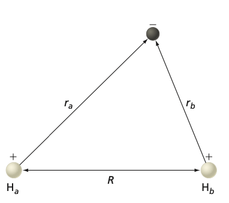

- $H_2^+$: **one electron**, two protons.
- Cleanest model of a **chemical bond**.
- Electron at $\vec{r}_1$, protons at $\vec{R}_A$, $\vec{R}_B$.
- Internuclear distance $R = |\vec{R}_A - \vec{R}_B|$.

## The Full Hamiltonian

- Kinetic energy of **both nuclei and electron**, plus Coulomb terms.

$$\hat{H} = -\frac{\hbar^2}{2M}(\Delta_A + \Delta_B) - \frac{\hbar^2}{2m_e}\Delta_e + \frac{e^2}{4\pi\epsilon_0}\left(\frac{1}{R} - \frac{1}{r_{1A}} - \frac{1}{r_{1B}}\right)$$

- Wavefunction depends on **all** coordinates: $\psi(\vec{r}_1, \vec{R}_A, \vec{R}_B)$.

## The Key Insight: Mass

- Proton mass $M$ is about **1800 times** the electron mass $m_e$.
- Electrons are **fast and light**; nuclei are **slow and heavy**.
- Electrons adjust **instantly** to any nuclear position.
- So freeze the nuclei, then solve for the electron.

## Separating the Wavefunction

- Split into an **electronic** and a **nuclear** part.

$$\psi(\vec{r}_1, \vec{R}_A, \vec{R}_B) = \psi_e(\vec{r}_1, R)\,\psi_n(\vec{R}_A, \vec{R}_B)$$

- $\psi_e$ depends on $R$ as a **parameter**, not a variable.
- $\psi_n$ further splits into **vibration, rotation, translation**.

## The Electronic Schrodinger Equation

$$\hat{H}_e\,\psi_e = E_e\,\psi_e$$

$$\hat{H}_e = -\frac{\hbar^2}{2m_e}\Delta_e + \frac{e^2}{4\pi\epsilon_0}\left(\frac{1}{R} - \frac{1}{|r_1 - R_A|} - \frac{1}{|r_1 - R_B|}\right)$$

- **No nuclear kinetic energy**: the nuclei are frozen.
- One equation **for each value** of $R$.

## R is a Parameter, Not a Variable

- Solve the electronic problem at a **fixed geometry**.
- Both the energy and the orbital depend on $R$:
  $$E_e = E_e(R), \qquad \psi_e = \psi_e(R)$$
- Change $R$, get a **new** energy and a **new** wavefunction.

## The Potential Energy Surface

- Sweep $R$ across many fixed geometries.
- Each solution gives one point $E_e(R)$.
- Together they trace the **potential energy surface**.
- The nuclei then **move on this surface**.
- This is what makes electronic structure **tractable**.

## Molecular Orbitals

- The single-electron wavefunctions of a molecule.
- Called **molecular orbitals (MOs)**.
- The molecular analog of **atomic orbitals**.
- Each geometry $R$ gives its **own set** of MOs.

## Born and Oppenheimer

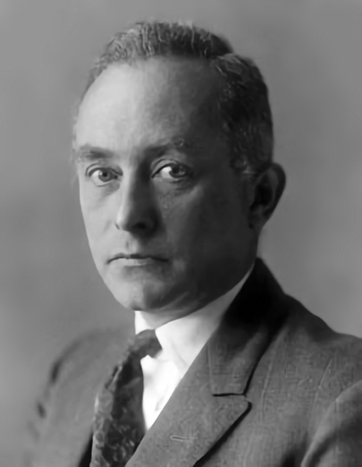

Max Born

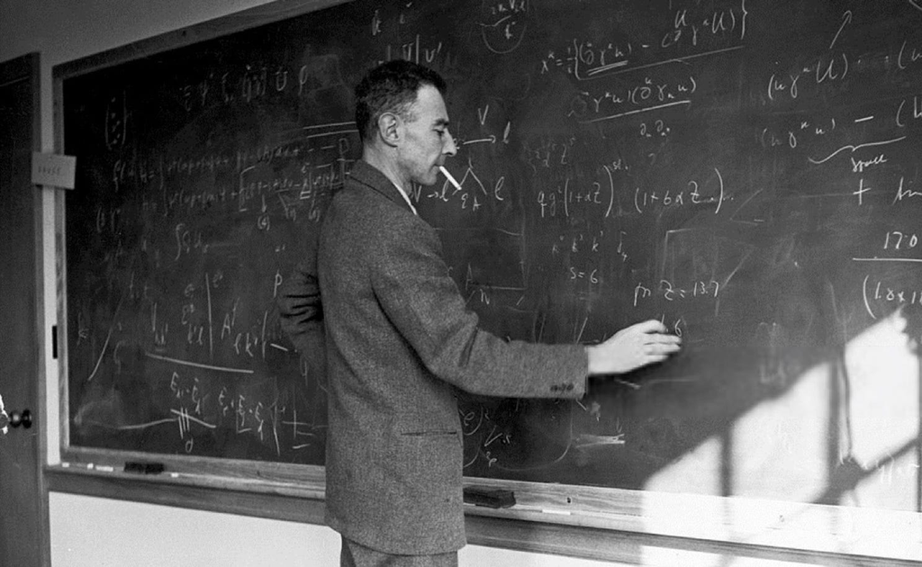

Robert J. Oppenheimer

- Their 1927 separation underpins **all** of molecular quantum chemistry.

# Takeaway

> Because nuclei are far heavier than electrons, the molecular wavefunction **separates** into electronic and nuclear parts. Solving $\hat{H}_e\psi_e = E_e\psi_e$ at each **fixed** nuclear geometry $R$ yields molecular orbitals and traces the **potential energy surface** on which the nuclei move.